# Activity data analytics - Practical Machine Learning Final Project

Dimitrios Andriopoulos

November 2021

## 1. Synopsis

This project explores the quality of activities performed by 6 participants. The data is used from accelerometers on th belt, forearm, arm, and dumbell. As can be seen, the most accurate prediction model is random forests.

## 2. Data processing

The Weight Lifting Exercise Dataset contains ther relevant datasets on the website http://web.archive.org/web/20161224072740/http:/groupware.les.inf.puc-rio.br/har

### 2.1 Reading in the Personal activity data

```r
url.train<-"https://d396qusza40orc.cloudfront.net/predmachlearn/pml-training.csv"
url.test<-"https://d396qusza40orc.cloudfront.net/predmachlearn/pml-testing.csv"
destfile.train<-"/Users/dimitriosandriopoulos/Practical_machine_learning_final_submission/gitrepos/practicalmachinelearning/train.csv"
destfile.test<-"/Users/dimitriosandriopoulos/Practical_machine_learning_final_submission/gitrepos/practicalmachinelearning/test.csv"
download.file(url.train,destfile.train)
download.file(url.test,destfile.test)

train <- read.csv("train.csv", na.strings = c("NA","#DIV/0!",""))
test <- read.csv("test.csv", na.strings = c("NA","#DIV/0!",""))
```

### 2.2 Cleaning the input data & exploratory data analysis & data preparation

```r
#Perform exploratory data analysis
#summary(test); summary(train); str(train); str(test)

#Data cleaning
#delete columns with all NA's
train<-train[,colSums(is.na(train)) == 0]
test <-test[,colSums(is.na(test)) == 0]

#remove irrelevant variables
train<-train[-c(1:7)]
test<-test[-c(1:7)]

train$classe<-as.factor(train$classe) #convert the outcome to factor with levels A through E

#Partition the train data into a testing/validation set and a training set
set.seed(123)
inTrain<-createDataPartition(y=train$classe, p=0.75, list=F)

training<-train[inTrain,]
testing<-train[-inTrain,]
```

The table below, shows that each classe has similar frequencies, A being an exception.

```r
table(training$classe); table(testing$classe)
```

```
   A    B    C    D    E
4185 2848 2567 2412 2706
```

```
   A    B    C    D    E
1395  949  855  804  901
```

## 3. Model selection and training

### 3.1 Simple prediction trees

As our outcome variable is composed of 5 classes (A) through (E), I will apply prediction models with Trees. Specifically, I will use the standard “rpart” tree and then random forests. I will compare the two.

```r
library(caret)
modFit1<-rpart(classe ~., data = training, method = "class") # training the model using all predictors and method rpart
pred1<-predict(modFit1, testing, type = "class")
cm1<-confusionMatrix(pred1,as.factor(testing$classe))
cm1
```

```
Confusion Matrix and Statistics

          Reference
Prediction    A    B    C    D    E
         A 1304  185   31  102   45
         B   28  479   34   16   29
         C   25  125  689  130  109
         D   18   69   37  477   50
         E   20   91   64   79  668

Overall Statistics

               Accuracy : 0.7376
                 95% CI : (0.725, 0.7498)
    No Information Rate : 0.2845
    P-Value [Acc > NIR] : < 2.2e-16

                  Kappa : 0.6659

 Mcnemar's Test P-Value : < 2.2e-16

Statistics by Class:

                     Class: A Class: B Class: C Class: D Class: E
Sensitivity            0.9348  0.50474   0.8058  0.59328   0.7414
Specificity            0.8966  0.97295   0.9039  0.95756   0.9365
Pos Pred Value         0.7822  0.81741   0.6391  0.73272   0.7245
Neg Pred Value         0.9719  0.89115   0.9566  0.92311   0.9415
Prevalence             0.2845  0.19352   0.1743  0.16395   0.1837
Detection Rate         0.2659  0.09768   0.1405  0.09727   0.1362
Detection Prevalence   0.3399  0.11949   0.2198  0.13275   0.1880
Balanced Accuracy      0.9157  0.73884   0.8549  0.77542   0.8390
```

```r
#Accuracy of prediction trees
accu1<-cm1$overall
```

Below, follows an rpart.plot of the prediction tree I built above:

```r
library(rattle)
```

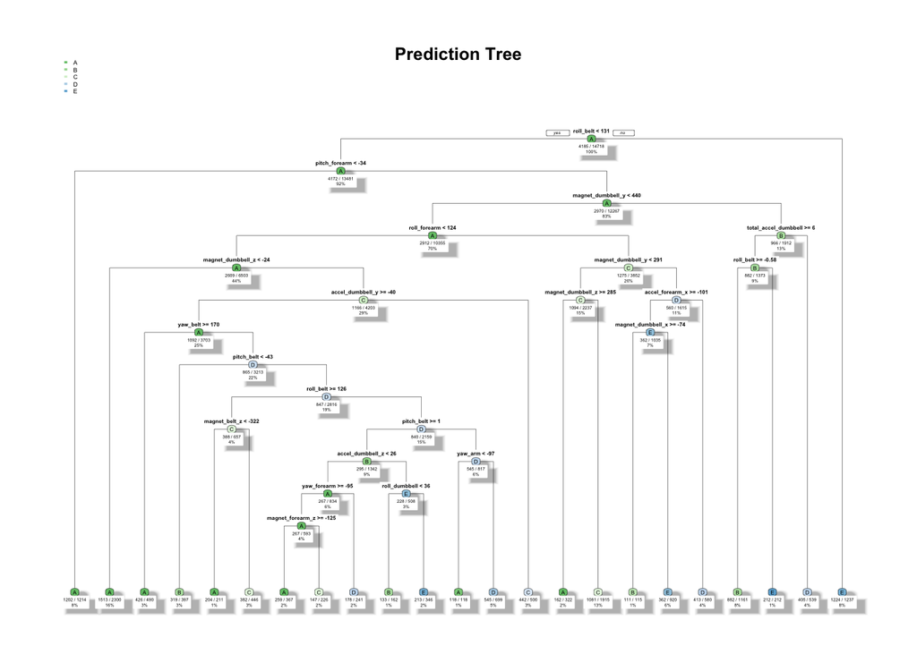

```r
rpart.plot(modFit1, main="Prediction Tree", type = 1, extra=102 ,under=TRUE, faclen=0, box.palette="GnBu", shadow.col="gray")
```

As, can be seen in simple prediction tree above, the accuracy achieved was 73% overall. The confusion matrix illustrates the cases where the algorithm misclassified.

### 3.2 Random forests

Next, as random forests are one of the top prediction algorithms, I will check their efficacy in this situatuion.

```r
#After attempting to run random forests using the caret package, I switched to the randomForest function from the randomForest package directly; the train function from caret was taking too long.
library(randomForest)

rf<-randomForest(classe ~., data = training, method = "class") # training the model using all predictors and method random forests

pred2<-predict(rf, testing, type = "class")
cm2<-confusionMatrix(pred2,as.factor(testing$classe))
cm2
```

```
Confusion Matrix and Statistics

          Reference
Prediction    A    B    C    D    E
         A 1395    0    0    0    0
         B    0  948    9    0    0
         C    0    1  846    6    0
         D    0    0    0  798    2
         E    0    0    0    0  899

Overall Statistics

               Accuracy : 0.9963
                 95% CI : (0.9942, 0.9978)
    No Information Rate : 0.2845
    P-Value [Acc > NIR] : < 2.2e-16

                  Kappa : 0.9954

 Mcnemar's Test P-Value : NA

Statistics by Class:

                     Class: A Class: B Class: C Class: D Class: E
Sensitivity            1.0000   0.9989   0.9895   0.9925   0.9978
Specificity            1.0000   0.9977   0.9983   0.9995   1.0000
Pos Pred Value         1.0000   0.9906   0.9918   0.9975   1.0000
Neg Pred Value         1.0000   0.9997   0.9978   0.9985   0.9995
Prevalence             0.2845   0.1935   0.1743   0.1639   0.1837
Detection Rate         0.2845   0.1933   0.1725   0.1627   0.1833
Detection Prevalence   0.2845   0.1951   0.1739   0.1631   0.1833
Balanced Accuracy      1.0000   0.9983   0.9939   0.9960   0.9989
```

## Results & Prediction

```r
rf.predict<-predict(rf,test,type = "class")
rf.predict
```

```
 1  2  3  4  5  6  7  8  9 10 11 12 13 14 15 16 17 18 19 20
 B  A  B  A  A  E  D  B  A  A  B  C  B  A  E  E  A  B  B  B
Levels: A B C D E
```

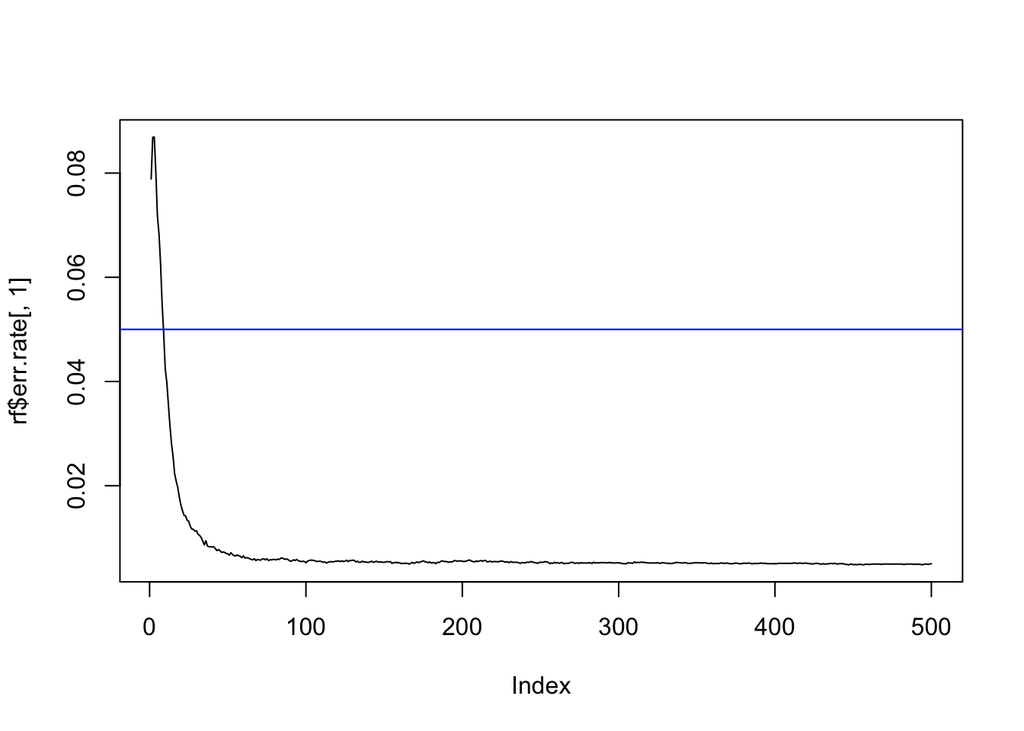

```r
plot(rf$err.rate[,1], type = "l")
abline(h=0.05, col="blue")
```